# Biofilme – detecção fenotípica

Luiza Souza Rodrigues e [Henrique Laureano](https://henriquelaureano.github.io/)

Last modification on* 2022-06-28 08:44:59

# CV 0.1%

> File: *Biofilme_placa07.06.2022_01CV.xlsx*

> **Placa 1**

```
       Mínimo    1o.quantil       Mediana         Média    3o.quantil        Máximo Desvio.Padrão
       0.1230        0.7532        2.1770        2.0445        3.2585        3.8120        1.2831
```

> **Placa 2**

```
       Mínimo    1o.quantil       Mediana         Média    3o.quantil        Máximo Desvio.Padrão
       0.1230        0.7525        2.1755        2.0430        3.2525        3.8120        1.2822
```

> **Variação entre duplicatas**

```
       Mínimo    1o.quantil       Mediana         Média    3o.quantil        Máximo Desvio.Padrão
       0.0000        0.0010        0.0020        0.0035        0.0040        0.0390        0.0055
```

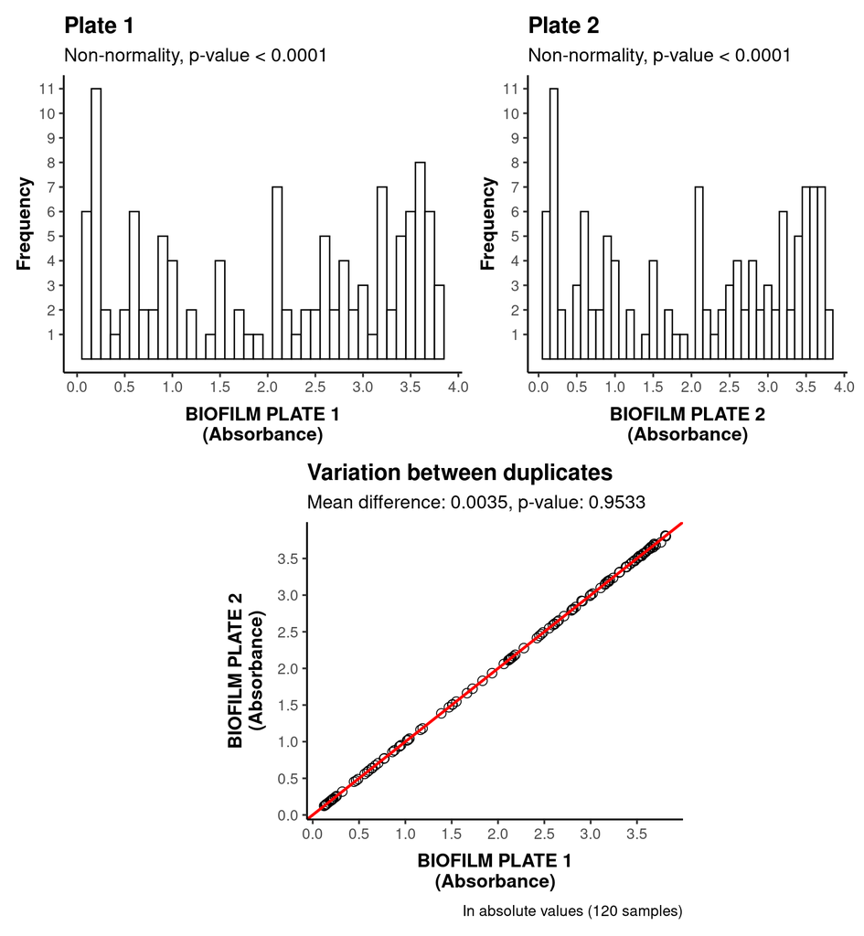

> **Interpretação final**

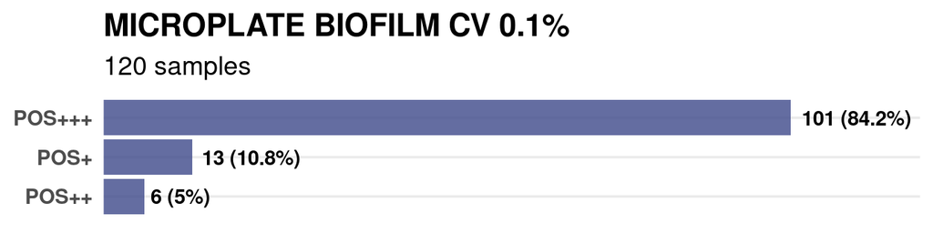

# CV 1%

> File: *Biofilme_placa07.06.2022_1CV.xlsx*

> **Placa 1**

```
       Mínimo    1o.quantil       Mediana         Média    3o.quantil        Máximo Desvio.Padrão
       0.1310        0.7905        2.9800        2.4215        3.8270        4.0000        1.4887
```

> **Placa 2**

```
       Mínimo    1o.quantil       Mediana         Média    3o.quantil        Máximo Desvio.Padrão
       0.1310        0.7885        2.9855        2.4226        3.8368        4.0000        1.4908
```

> **Variação entre duplicatas**

```
       Mínimo    1o.quantil       Mediana         Média    3o.quantil        Máximo Desvio.Padrão
       0.0000        0.0010        0.0020        0.0083        0.0112        0.0580        0.0121
```

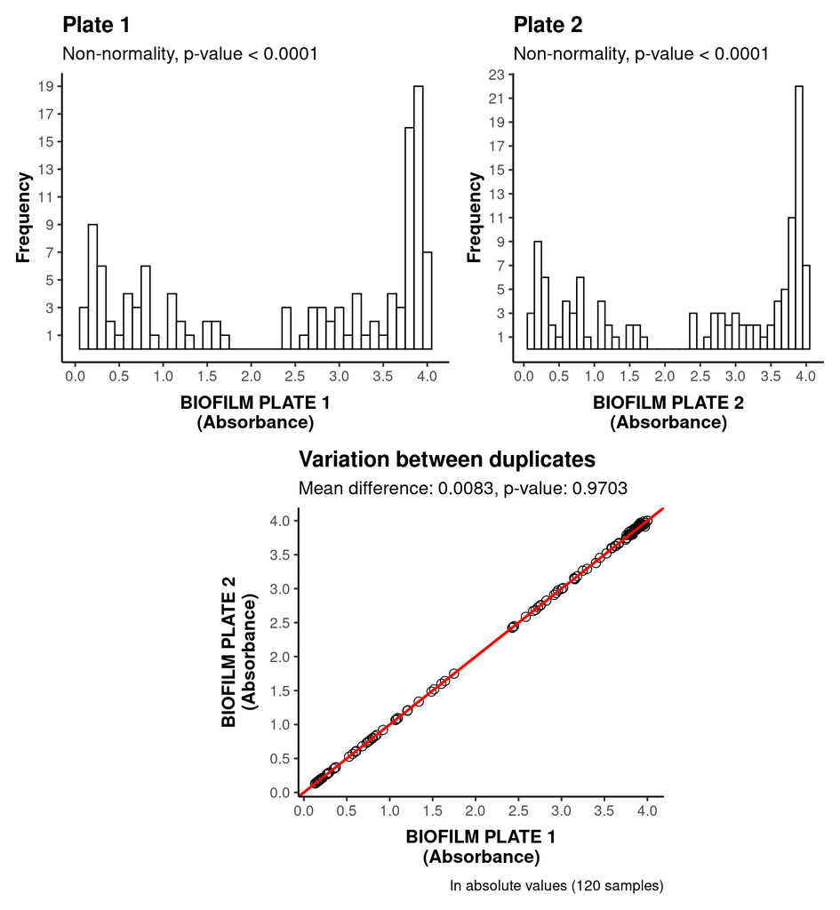

> **Interpretação final**

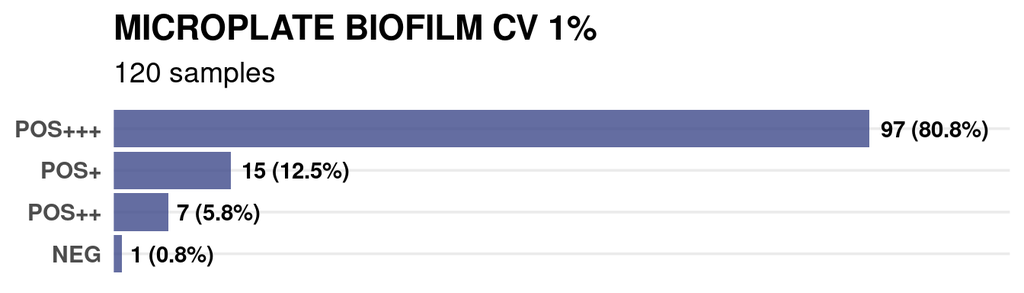

# Tubo

> File: *Biofilme_tubo07.06.2022_CV.xlsx*

> **Interpretação final**

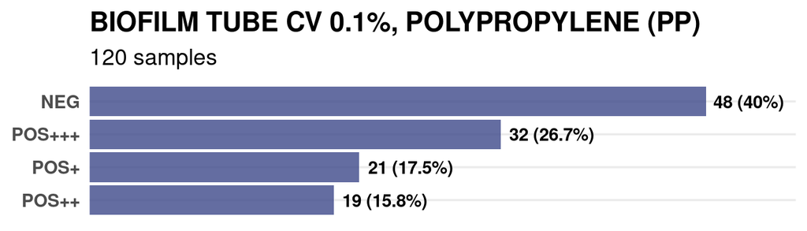

> Quando comparamos os resultados dados pelos três analistas, chegamos em 14 combinações existentes. Ordenamos elas por frequência e calculamos seus respectivos percentuais.

```
# A tibble: 14 × 5
   `Analista 1` `Analista 2` `Analista 3`     n percentual
   <chr>        <chr>        <chr>        <int>      <dbl>
 1 NEG          NEG          NEG             40    0.333
 2 POS+++       POS+++       POS+++          32    0.267
 3 POS+         POS+         POS+            12    0.1
 4 POS++        POS++        POS++           10    0.0833
 5 NEG          POS+         NEG              6    0.05
 6 POS+         POS++        POS+             6    0.05
 7 POS+         POS++        POS++            3    0.025
 8 POS+         NEG          NEG              2    0.0167
 9 POS+         POS+         POS++            2    0.0167
10 POS++        POS+++       POS++            2    0.0167
11 POS+++       POS++        POS++            2    0.0167
12 NEG          POS+         POS+             1    0.00833
13 POS++        POS++        POS+             1    0.00833
14 POS++        POS+++       POS+++           1    0.00833
```

> Simplificando mais, em 78% dos casos houve um consenso entre os três analistas.

> Essa diferença (94 (78%) vs. 26 (22%)) é estatísticamente significativa, ou seja, de maneira significativa os três analistas entram mais em consenso do que o contrário.

```
# A tibble: 2 × 3
  consenso     n percentual
  <chr>    <int>      <dbl>
1 Não         26      0.217
2 Sim         94      0.783
```

```
Test statistic.X-squared                  p-value
            38.533333333              0.000000001
```

> Destacamos as 10 combinações (26 vezes, 22%) em que não houve consenso entre os analistas.

```
# A tibble: 10 × 5
   `Analista 1` `Analista 2` `Analista 3`     n percentual
   <chr>        <chr>        <chr>        <int>      <dbl>
 1 NEG          POS+         NEG              6    0.05
 2 POS+         POS++        POS+             6    0.05
 3 POS+         POS++        POS++            3    0.025
 4 POS+         NEG          NEG              2    0.0167
 5 POS+         POS+         POS++            2    0.0167
 6 POS++        POS+++       POS++            2    0.0167
 7 POS+++       POS++        POS++            2    0.0167
 8 NEG          POS+         POS+             1    0.00833
 9 POS++        POS++        POS+             1    0.00833
10 POS++        POS+++       POS+++           1    0.00833
```

# Comparando interpretações finais

> Quando comparamos os três testes, seus resultados geraram 19 combinações possíveis.

```
     01CV    1CV   TUBO  n  percentual
1  POS+++ POS+++    NEG 39 0.325000000
2  POS+++ POS+++ POS+++ 29 0.241666667
3  POS+++ POS+++  POS++ 17 0.141666667
4  POS+++ POS+++   POS+ 11 0.091666667
5    POS+   POS+    NEG  4 0.033333333
6    POS+   POS+   POS+  4 0.033333333
7  POS+++  POS++   POS+  3 0.025000000
8    POS+   POS+ POS+++  2 0.016666667
9    POS+    NEG    NEG  1 0.008333333
10   POS+   POS+  POS++  1 0.008333333
11   POS+  POS++   POS+  1 0.008333333
12  POS++   POS+    NEG  1 0.008333333
13  POS++   POS+   POS+  1 0.008333333
14  POS++   POS+  POS++  1 0.008333333
15  POS++  POS++    NEG  1 0.008333333
16  POS++  POS++ POS+++  1 0.008333333
17  POS++ POS+++    NEG  1 0.008333333
18 POS+++   POS+   POS+  1 0.008333333
19 POS+++  POS++    NEG  1 0.008333333
```

> Houve um consenso em apenas 27% das vezes (diferença significativa, i.e. se diverge mais do que se entra em consenso).

```
# A tibble: 2 × 3
  consenso     n percentual
  <chr>    <int>      <dbl>
1 Não         87      0.725
2 Sim         33      0.275
```

```
Test statistic.X-squared                  p-value
                    24.3                      0.0
```

> No gráfico abaixo representamos visualmente em forma de fluxos tudo que é fornecido na primeira tabela (19 combinações).

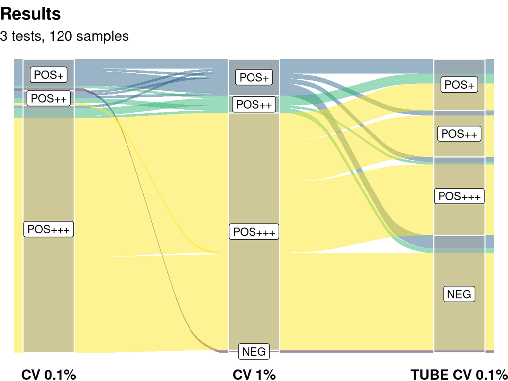

> A seguir comparamos os testes um-contra-outro.

## CV 0.1% vs. CV 1%

```
    01CV    1CV  n  percentual
1 POS+++ POS+++ 96 0.800000000
2   POS+   POS+ 11 0.091666667
3 POS+++  POS++  4 0.033333333
4  POS++   POS+  3 0.025000000
5  POS++  POS++  2 0.016666667
6   POS+    NEG  1 0.008333333
7   POS+  POS++  1 0.008333333
8  POS++ POS+++  1 0.008333333
9 POS+++   POS+  1 0.008333333
```

> Existe um consenso (de maneira significativa) em 91% das vezes.

```
# A tibble: 2 × 3
  consenso     n percentual
  <chr>    <int>      <dbl>
1 Não         11     0.0917
2 Sim        109     0.908
```

```
Test statistic.X-squared                  p-value
                 80.0333                   0.0000
```

## CV 0.1% vs. Tubo

```
     01CV   TUBO  n  percentual
1  POS+++    NEG 40 0.333333333
2  POS+++ POS+++ 29 0.241666667
3  POS+++  POS++ 17 0.141666667
4  POS+++   POS+ 15 0.125000000
5    POS+    NEG  5 0.041666667
6    POS+   POS+  5 0.041666667
7   POS++    NEG  3 0.025000000
8    POS+ POS+++  2 0.016666667
9    POS+  POS++  1 0.008333333
10  POS++   POS+  1 0.008333333
11  POS++  POS++  1 0.008333333
12  POS++ POS+++  1 0.008333333
```

> Consenso em 29% das vezes, ou seja, se diverge mais (de maneira significativa).

```
# A tibble: 2 × 3
  consenso     n percentual
  <chr>    <int>      <dbl>
1 Não         85      0.708
2 Sim         35      0.292
```

```
Test statistic.X-squared                  p-value
             20.83333333               0.00000501
```

## CV 1% vs. Tubo

```
      1CV   TUBO  n  percentual
1  POS+++    NEG 40 0.333333333
2  POS+++ POS+++ 29 0.241666667
3  POS+++  POS++ 17 0.141666667
4  POS+++   POS+ 11 0.091666667
5    POS+   POS+  6 0.050000000
6    POS+    NEG  5 0.041666667
7   POS++   POS+  4 0.033333333
8    POS+  POS++  2 0.016666667
9    POS+ POS+++  2 0.016666667
10  POS++    NEG  2 0.016666667
11    NEG    NEG  1 0.008333333
12  POS++ POS+++  1 0.008333333
```

> Consenso em 30% das vezes, ou seja, se diverge mais (de maneira significativa).

```
# A tibble: 2 × 3
  consenso     n percentual
  <chr>    <int>      <dbl>
1 Não         84        0.7
2 Sim         36        0.3
```

```
Test statistic.X-squared                  p-value
                19.20000                  0.00001
```

## Comentários finais

> 01CV e 1CV geram resultados concordantes entre si (91% das vezes, significativo), enquanto que ambos diferem significativamente do Tubo.

# ID-MALDI-TOF

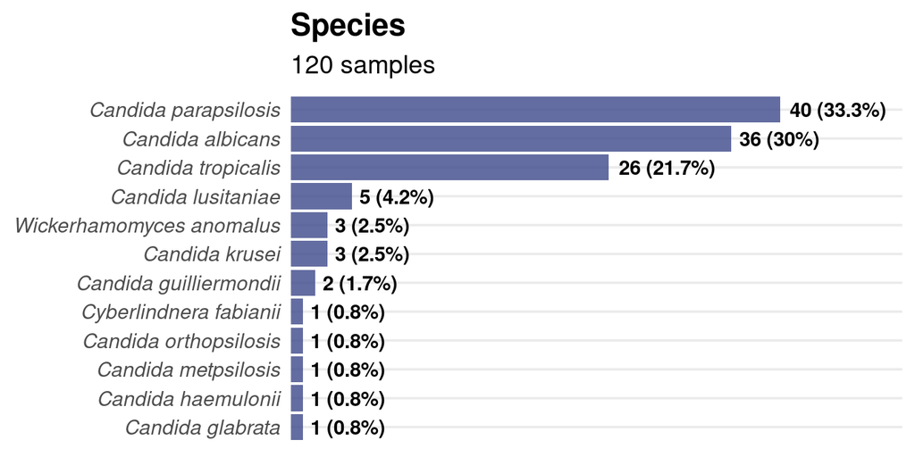

## *Candida albicans*

```
# A tibble: 1 × 4
  `01CV` `1CV`  TUBO      n
  <chr>  <chr>  <chr> <int>
1 POS+++ POS+++ NEG      36
```

> Em todas as 36 ocorrências dessa espécie o resultado foi o mesmo.

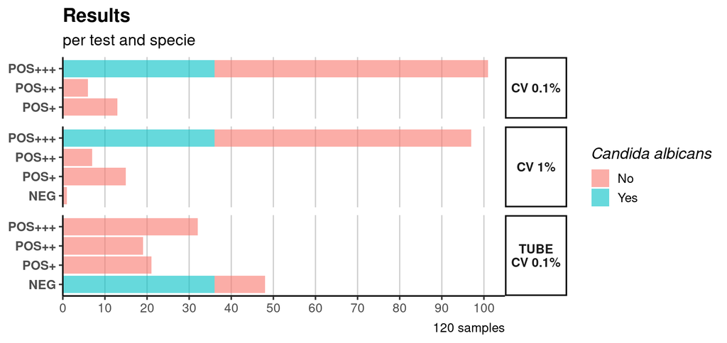

## Três espécies mais frequentes

> As três espécies mais frequentes correspondem a 85% (102) das amostras.

```
# A tibble: 14 × 6
   SPECIE               `01CV` `1CV`  TUBO       n percentual
   <chr>                <chr>  <chr>  <chr>  <int>      <dbl>
 1 Candida albicans     POS+++ POS+++ NEG       36    0.353
 2 Candida parapsilosis POS+++ POS+++ POS++     15    0.147
 3 Candida parapsilosis POS+++ POS+++ POS+      10    0.0980
 4 Candida parapsilosis POS+   POS+   NEG        3    0.0294
 5 Candida parapsilosis POS+++ POS++  POS+       3    0.0294
 6 Candida parapsilosis POS+++ POS+++ NEG        2    0.0196
 7 Candida parapsilosis POS+++ POS+++ POS+++     2    0.0196
 8 Candida parapsilosis POS+   NEG    NEG        1    0.00980
 9 Candida parapsilosis POS+   POS+   POS+       1    0.00980
10 Candida parapsilosis POS++  POS+   POS+       1    0.00980
11 Candida parapsilosis POS++  POS+++ NEG        1    0.00980
12 Candida parapsilosis POS+++ POS+   POS+       1    0.00980
13 Candida tropicalis   POS+++ POS+++ POS+++    25    0.245
14 Candida tropicalis   POS++  POS++  NEG        1    0.00980
```

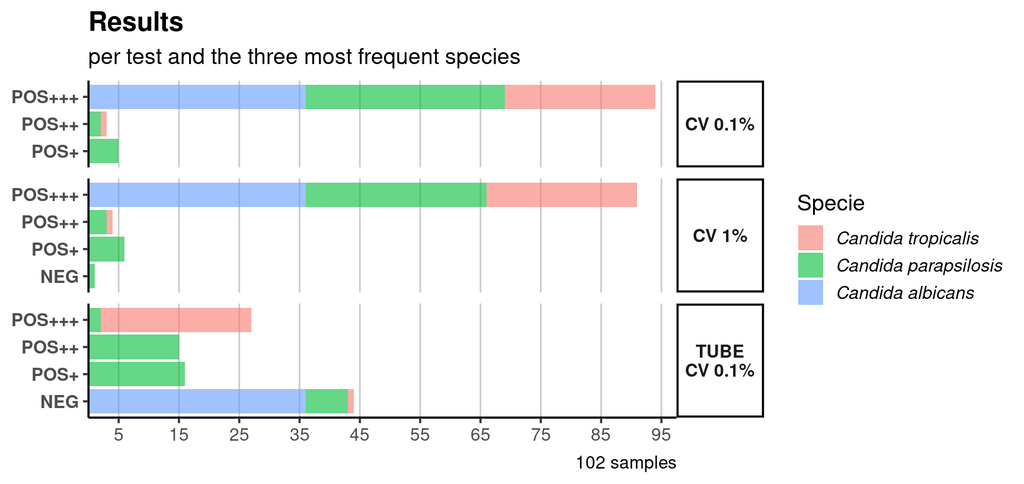

## Testando hipótese

> “*Entre os resultados que deram positivo na microplaca e negativo na técnica em tubo, parece que isso aconteceu com maior frequência para microrganismos do tipo C. albicans, queríamos ver se a espécie teve diferença estatística das demais neste senntido; pois suspeitamos que o teste seja menos sensível especificamente para ela.*”

> Em 47 (39.2%) dos casos aconteceu de dar negativo em tubo e positivo na microplaca. Destes 47, em 36 (77%) a espécie é a *C. albicans*.

```
# A tibble: 6 × 3
  SPECIE                     n percentual
  <chr>                  <int>      <dbl>
1 Candida albicans          36     0.766
2 Candida parapsilosis       6     0.128
3 Candida lusitaniae         2     0.0426
4 Candida guilliermondii     1     0.0213
5 Candida orthopsilosis      1     0.0213
6 Candida tropicalis         1     0.0213
```

```
# A tibble: 2 × 3
  albicans     n percentual
  <chr>    <int>      <dbl>
1 Não         11      0.234
2 Sim         36      0.766
```

```
Test statistic.X-squared                  p-value
                13.29787                  0.00027
```

> Essa diferença é estatisticamente significativa. Ou seja, nas situações em que o tubo deu negativo e a microplaca deu positivo, a espécie *C. albicans* se destacou/teve a maior frequência de maneira (estatisticamente) significativa.

# Referências

> A análise estatística foi realizada no ambiente de computação estatística `R` (R Core Team, 2022). Os principais pacotes `R` utilizados foram o {`readxl`} (Wickham & Bryan, 2022), {`tidyr`} (Wickham & Girlich, 2022), {`dplyr`} (Wickham et al., 2022), {`haven`} (Wickham et al., 2022), {`ggplot2`} (Wickham, 2016), {`patchwork`} (Pedersen, 2020), {`tibble`} (Müller & Wickham, 2022), e {`ggalluvial`} (Brunson & Read, 2020).

> A normalidade das medidas das placas (01CV e 1CV) foi verificada via o Teste de Shapiro-Wilk (Royston, 1982a; Royston 1982b; Royston 1995), e como tal normalidade não foi observada, comparamos suas duplicatas via o Teste de Wilcoxon (*Wilcoxon rank sum test*, a versão não-paramétrica do Teste-*t*) (Bauer, 1972; Hollander & Wolfe, 1999). Para comparar os resultados dos testes utlizamos o Teste Qui-Quadrado de Pearson (Patefield, 1981; Agresti, 2007).

> R Core Team (2022). R: A language and environment for statistical computing. R Foundation for Statistical Computing, Vienna, Austria. URL https://www.R-project.org/

> Wickham, H., Bryan, J. (2022). readxl: Read Excel Files. R package version 1.4.0, https://CRAN.R-project.org/package=readxl

> Wickham, H., Girlich, M. (2022). tidyr: Tidy Messy Data. R package version 1.2.0, https://CRAN.R-project.org/package=tidyr

> Wickham, H., François, R., Henry, L., Müller, K. (2022). dplyr: A Grammar of Data Manipulation. R package version 1.0.9. https://CRAN.R-project.org/package=dplyr

> Wickham, H,, Miller, E., Smith, D. (2022). haven: Import and Export ‘SPSS’, ‘Stata’ and ‘SAS’ Files. R package version 2.5.0, https://CRAN.R-project.org/package=haven

> Wickham, H. (2016). ggplot2: Elegant Graphics for Data Analysis. Springer-Verlag New York

> Pedersen, T. (2020). patchwork: The Composer of Plots. R package version 1.1.1, https://CRAN.R-project.org/package=patchwork

> Müller, K., Wickham, H. (2022). tibble: Simple Data Frames. R package version 3.1.7, https://CRAN.R-project.org/package=tibble

> Brunson, J. C., Read, Q. D. (2020). ggalluvial: Alluvial Plots in ‘ggplot2’. R package version 0.12.3, http://corybrunson.github.io/ggalluvial/

> Royston, P. (1982a). An extension of Shapiro and Wilk’s W test for normality to large samples. Applied Statistics, *31*, 115-124. https://doi.org/10.2307/2347973

> Royston, P. (1982b). Algorithm AS 181: The W test for Normality. Applied Statistics, *31*, 176-180. https://doi.org/10.2307/2347986

> Royston, P. (1995). Remark AS R94: A remark on Algorithm AS 181: The W test for normality. Applied Statistics, *44*, 547-551. https://doi.org/10.2307/2986146

> Bauer, D. F. (1972). Constructing confidence sets using rank statistics. Journal of the American Statistical Association *67*, 687-690. https://doi.org/10.1080/01621459.1972.10481279

> Hollander, M., Wolfe, D. A. (1999). Nonparametric Statistical Methods. New York: John Wiley & Sons

> Patefield, W. M. (1981). Algorithm AS 159: An efficient method of generating r x c tables with given row and column totals. Applied Statistics, *30*, 91-97. https://doi.org/10.2307/2346669

> Agresti, A. (2007). An Introduction to Categorical Data Analysis, 2nd ed. New York: John Wiley & Sons